# Final Exam - QBS 122 Spring 2021

## Author: Vala Zeinali

### Due Date: June 8th, 11:59pm

# Hierarchical Modeling

1) Use the longcostclass2.dta data set analyzed in class and in Homework 3. We are interested in the effect of the use of an atypical antipsychotic on the log of mental health costs, denoted mhcost. Throughout the question, treat year (denoted fyr) as a continuous variable and adjust for year, dxsud, age, female, black, other-non-white, ssi and area. You will find the lm, gls, and lmer procedures in R helpful.

a. Estimate and interpret the following two models

```
      i. Standard linear regression model with the lagged value of mhcost,
      denoted lagmhcost, as an additional predictor

      ii. Linear repeated-measures regression model that does not include
      lagmhcost as a predictor but assumes an AR(1) structure on the residuals
```

b. Do the models make different assumptions with respect to statistical dependence between the observations?

c. Is (i) or (ii) preferrable from the standpoint of sample-size and thus precision of estimation?

d. Re-estimate the model in (ii) but with an AR(2) error structure. What do the results imply about the adequacy of the model in (ii)?

e. Estimate the model like (ii) but with a random-intercept, random-slope effect for individual as opposed to an autoregressive error structure.

```
 i. Explain the meaning of the standard deviation of the random slope term

 ii. What is the value of the estimated correlation between the individual random intercept and random slopes? Is there evidence of regression to the mean across time?
```

```r
# load in packages
defaultW <- getOption("warn")
options(warn = -1)

library(readstata13)
library(Hmisc)
library(lme4)
library(Zelig)
library(gee)
library(prediction)
library(margins)
library(multcomp)
library(lsmeans)
library(emmeans)
library(nlme)
library(optimx)

options(warn = defaultW)
```

```r
# loading in the data

data<-read.dta13("longcostclass2.dta")

data$mhcost=log(data$mhcost)
data$bmhcost=ifelse(data$mhcost>median(data$mhcost),1,0)

#Re-compute lagged values of annual mental health costs (as noise added to real values)
ind=c(FALSE,(data$id[2:nrow(data)]==data$id[1:(nrow(data)-1)]))
data$lagmhcost=c(0,data$mhcost[1:(nrow(data)-1)])
data$lagmhcost[!ind]=NA
data$lagbmhcost=c(0,data$bmhcost[1:(nrow(data)-1)])
data$lagbmhcost[!ind]=NA
data$lagapsyat[!ind]=NA
data$start=data$apsyat*(1-data$lagapsyat)
data$stop=(1-data$apsyat)*data$lagapsyat
data$both=data$apsyat*data$lagapsyat
data$neither=(1-data$apsyat)*(1-data$lagapsyat)
data$change=1*(data$apsyat-data$lagapsyat>0) #1 or 0
data$dirchange=data$apsyat-data$lagapsyat #1 if start, -1 if stop, 0 otherwise
```

```r
head(data)
```

A data.frame: 6 × 33

|  | id <dbl> | usezyprexa <dbl> | useseroquel <dbl> | userisperda <dbl> | usegeodon <dbl> | zyprexa <dbl> | seroquel <dbl> | risperda <dbl> | geodon <dbl> | apsyat <dbl> | ⋯ | keep <dbl> | mhcost <dbl> | bmhcost <dbl> | lagbmhcost <dbl> | start <dbl> | stop <dbl> | both <dbl> | neither <dbl> | change <dbl> | dirchange <dbl> |
| --- | --- | --- | --- | --- | --- | --- | --- | --- | --- | --- | --- | --- | --- | --- | --- | --- | --- | --- | --- | --- | --- |
| 1 | 1 | 0 | 0 | 0 | 0 | 0 | 0 | 1 | 0 | 0 | ⋯ | 1 | 9.899456 | 1 | NA | NA | NA | NA | NA | NA | NA |
| 2 | 1 | 0 | 0 | 0 | 0 | 0 | 0 | 1 | 0 | 0 | ⋯ | 1 | 9.924738 | 1 | 1 | 0 | 0 | 0 | 1 | 0 | 0 |
| 3 | 11 | 1 | 0 | 1 | 0 | 1 | 1 | 1 | 0 | 1 | ⋯ | 1 | 10.317729 | 1 | NA | NA | NA | NA | NA | NA | NA |
| 4 | 11 | 1 | 1 | 0 | 1 | 1 | 1 | 1 | 1 | 1 | ⋯ | 1 | 9.389728 | 1 | 1 | 0 | 0 | 1 | 0 | 0 | 0 |
| 5 | 21 | 0 | 0 | 1 | 0 | 1 | 1 | 1 | 0 | 1 | ⋯ | 1 | 8.528903 | 1 | NA | NA | NA | NA | NA | NA | NA |
| 6 | 31 | 0 | 0 | 0 | 0 | 1 | 0 | 1 | 0 | 0 | ⋯ | 1 | 8.755748 | 1 | NA | NA | NA | NA | NA | NA | NA |

```r
# 1.a.i)

attach(data)
summary(out <- lm(mhcost ~ fyr + dxsud + age+ female + black+ othnonwht + ssi + lagmhcost + factor(area)))
```

```
Call:
lm(formula = mhcost ~ fyr + dxsud + age + female + black + othnonwht +
    ssi + lagmhcost + factor(area))

Residuals:
    Min      1Q  Median      3Q     Max
-5.6758 -0.4979  0.0214  0.4869  4.0064

Coefficients:
                Estimate Std. Error t value Pr(>|t|)
(Intercept)     2.612662   0.163901  15.940  < 2e-16 ***
fyr             0.057541   0.007855   7.325 2.75e-13 ***
dxsud           0.686368   0.042699  16.075  < 2e-16 ***
age            -0.002607   0.001290  -2.021  0.04331 *
female          0.089268   0.027380   3.260  0.00112 **
black          -0.047802   0.033224  -1.439  0.15027
othnonwht      -0.074459   0.033395  -2.230  0.02581 *
ssi             0.250804   0.114378   2.193  0.02837 *
lagmhcost       0.633860   0.009918  63.913  < 2e-16 ***
factor(area)2  -0.045271   0.085121  -0.532  0.59486
factor(area)3  -0.058833   0.078275  -0.752  0.45232
factor(area)4   0.028362   0.072686   0.390  0.69641
factor(area)5  -0.004197   0.074737  -0.056  0.95522
factor(area)6  -0.420011   0.092145  -4.558 5.28e-06 ***
factor(area)7   0.020973   0.075089   0.279  0.78002
factor(area)8   0.022925   0.092153   0.249  0.80355
factor(area)9  -0.025687   0.078377  -0.328  0.74312
factor(area)10  0.034679   0.072871   0.476  0.63417
factor(area)11  0.060084   0.061814   0.972  0.33109
---
Signif. codes:  0 ‘***’ 0.001 ‘**’ 0.01 ‘*’ 0.05 ‘.’ 0.1 ‘ ’ 1

Residual standard error: 0.9602 on 5232 degrees of freedom
  (2674 observations deleted due to missingness)
Multiple R-squared:  0.5064,	Adjusted R-squared:  0.5047
F-statistic: 298.2 on 18 and 5232 DF,  p-value: < 2.2e-16
```

### 1.a.ii) For every 1 unit increase in dxsud, there is a .68 increase in mhcost and is statistically significant (p-val < 2e-16). Assuming I.I.D and no co- multicollinearity.

```r
# 1.a.ii)

attach(data)
summary(modela <- gls(mhcost~fyr + dxsud + age+ female + black+ othnonwht + ssi + factor(area) ,
              correlation=corAR1()))
modela$modelStruct$corStruct
```

```
Generalized least squares fit by REML
  Model: mhcost ~ fyr + dxsud + age + female + black + othnonwht + ssi +      factor(area)
  Data: NULL
       AIC      BIC    logLik
  25872.16 26011.67 -12916.08

Correlation Structure: AR(1)
 Formula: ~1
 Parameter estimate(s):
      Phi
0.4100902

Coefficients:
                   Value  Std.Error  t-value p-value
(Intercept)     7.958375 0.13168171 60.43645  0.0000
fyr             0.074905 0.00735224 10.18802  0.0000
dxsud           1.062103 0.04431386 23.96774  0.0000
age            -0.006311 0.00156433 -4.03432  0.0001
female          0.167719 0.03648454  4.59698  0.0000
black          -0.162076 0.04377929 -3.70213  0.0002
othnonwht      -0.172049 0.04445549 -3.87014  0.0001
ssi             0.379217 0.07793264  4.86596  0.0000
factor(area)2  -0.135795 0.11594618 -1.17119  0.2416
factor(area)3  -0.406521 0.10572034 -3.84525  0.0001
factor(area)4  -0.003138 0.10044412 -0.03124  0.9751
factor(area)5  -0.124076 0.10244683 -1.21112  0.2259
factor(area)6  -0.704514 0.11087580 -6.35408  0.0000
factor(area)7  -0.262769 0.10315605 -2.54729  0.0109
factor(area)8  -0.641521 0.12388067 -5.17854  0.0000
factor(area)9  -0.281856 0.10944231 -2.57539  0.0100
factor(area)10 -0.080878 0.10006118 -0.80829  0.4189
factor(area)11 -0.123502 0.08906243 -1.38669  0.1656

 Correlation:
               (Intr) fyr    dxsud  age    female black  othnnw ssi    fct()2
fyr            -0.211
dxsud          -0.049 -0.011
age            -0.395 -0.108  0.048
female         -0.101  0.017  0.067 -0.200
black          -0.169 -0.018 -0.025  0.065 -0.019
```

[output cut: 22 more lines]

```
factor(area)4   0.638
factor(area)5   0.619  0.655
factor(area)6   0.572  0.608  0.588
factor(area)7   0.616  0.654  0.629  0.588
factor(area)8   0.514  0.546  0.533  0.491  0.532
factor(area)9   0.578  0.614  0.599  0.552  0.595  0.505
factor(area)10  0.634  0.673  0.658  0.607  0.651  0.544  0.619
factor(area)11  0.714  0.759  0.738  0.686  0.740  0.621  0.696  0.768

Standardized residuals:
       Min         Q1        Med         Q3        Max
-4.3232340 -0.6590935  0.1094547  0.7430514  2.3596063

Residual standard error: 1.348502
Degrees of freedom: 7925 total; 7907 residual
```

```
Correlation structure of class corAR1 representing
      Phi
0.4100902
```

### 1.b) The models make different assumptions with respect to statistical dependence between the observations. Our second model has an autoregressive error structure

### 1.c) Our second model named model is more diseriable for two reasons. It has about 8000 observations compared to the first model. In addition, the second model is worse because is has a higher AIC score compared to our first model. AIC score shown below.

```r
AIC(out) # first model
```

14496.6273409045

```r
AIC(modela) # second model
```

25872.1613472209

```r
# 1.d)

summary(modeld <- gls(mhcost~fyr + dxsud + age + female + black + othnonwht + ssi + factor(area) ,
             correlation=corARMA(form= ~1|id, p=2, q=0),data=data))
modeld$modelStruct$corStruct
```

```
Generalized least squares fit by REML
  Model: mhcost ~ fyr + dxsud + age + female + black + othnonwht + ssi +      factor(area)
  Data: data
       AIC      BIC    logLik
  24018.66 24165.14 -11988.33

Correlation Structure: ARMA(2,0)
 Formula: ~1 | id
 Parameter estimate(s):
     Phi1      Phi2
0.4977981 0.2866909

Coefficients:
                   Value  Std.Error  t-value p-value
(Intercept)     7.843269 0.16478836 47.59601  0.0000
fyr             0.069317 0.00755469  9.17533  0.0000
dxsud           0.885341 0.04096891 21.61007  0.0000
age            -0.004462 0.00207732 -2.14795  0.0317
female          0.149073 0.04931657  3.02277  0.0025
black          -0.185804 0.05939035 -3.12852  0.0018
othnonwht      -0.155558 0.05955343 -2.61207  0.0090
ssi             0.389112 0.08639741  4.50375  0.0000
factor(area)2  -0.150763 0.15531873 -0.97067  0.3317
factor(area)3  -0.437977 0.14255310 -3.07238  0.0021
factor(area)4  -0.049471 0.13642800 -0.36262  0.7169
factor(area)5  -0.145684 0.13999776 -1.04062  0.2981
factor(area)6  -0.712278 0.14632851 -4.86766  0.0000
factor(area)7  -0.300032 0.14083733 -2.13035  0.0332
factor(area)8  -0.608872 0.16467728 -3.69736  0.0002
factor(area)9  -0.285621 0.14803641 -1.92940  0.0537
factor(area)10 -0.103384 0.13591671 -0.76064  0.4469
factor(area)11 -0.146191 0.12322582 -1.18636  0.2355

 Correlation:
               (Intr) fyr    dxsud  age    female black  othnnw ssi    fct()2
fyr            -0.133
dxsud          -0.041 -0.013
age            -0.405 -0.177  0.035
female         -0.126  0.040  0.043 -0.182
black          -0.178 -0.020 -0.015  0.062 -0.025
```

[output cut: 22 more lines]

```
factor(area)4   0.693
factor(area)5   0.666  0.685
factor(area)6   0.637  0.660  0.654
factor(area)7   0.668  0.690  0.673  0.643
factor(area)8   0.563  0.581  0.576  0.561  0.567
factor(area)9   0.622  0.654  0.636  0.613  0.634  0.552
factor(area)10  0.682  0.709  0.692  0.665  0.690  0.589  0.664
factor(area)11  0.747  0.778  0.763  0.738  0.763  0.656  0.726  0.800

Standardized residuals:
       Min         Q1        Med         Q3        Max
-4.1076150 -0.5694435  0.1879590  0.8003240  2.3698375

Residual standard error: 1.392167
Degrees of freedom: 7925 total; 7907 residual
```

```
Correlation structure of class corARMA representing
     Phi1      Phi2
0.4977981 0.2866909
```

### 1.d) Since the Phi1 is .49, there is a Strong positive relationship between time and lagged time for t-1. Since the Phi2 is .286, there is a weak relationship between time and lagged time t-2 .For every 1 unit increase in dxsud, there is a .884 increase in mhcost and is statistically significant (p-val = 0). Assuming I.I.D and no co- multicollinearity. We made id an ordinal variable. Lower AIC when we use AR(2), we should stick with AR(2).

```r
# 1.e)
set.seed(1234)  # this will allow you to exactly duplicate your result

x= rnorm(7925)


summary(model_with_slopes <- lmer(mhcost~fyr + dxsud + age+ female + black+ othnonwht + ssi
                          + factor(area) + (1|id) + (0 + x|id), data = data))
```

[output not shown]

### e.i Intercept is most dominant random effect due to the greater std.

# Problem 2 of part 1

```r
data <- read.csv("FrenchAreaVariationsData.csv",head=T,sep=",")
head(data)
```

A data.frame: 6 × 6

|  | REGION.NO <int> | DEPT.NO <int> | Age <int> | Gender <int> | Pop <dbl> | NBACK <int> |
| --- | --- | --- | --- | --- | --- | --- |
| 1 | 82 | 1 | 65 | 1 | 11208.789 | 5 |
| 2 | 22 | 2 | 65 | 1 | 9699.532 | 2 |
| 3 | 83 | 3 | 65 | 1 | 8360.539 | 5 |
| 4 | 93 | 4 | 65 | 1 | 4155.313 | 9 |
| 5 | 93 | 5 | 65 | 1 | 3290.985 | 8 |
| 6 | 93 | 6 | 65 | 1 | 25893.205 | 36 |

```r
# 1.2.a
attach(data)
summary(outa <- glmer(NBACK~ Age + Gender+ offset(log(Pop))+(1|DEPT.NO)+(1|REGION.NO), family = poisson(link='log')))
```

```
Generalized linear mixed model fit by maximum likelihood (Laplace
  Approximation) [glmerMod]
 Family: poisson  ( log )
Formula: NBACK ~ Age + Gender + offset(log(Pop)) + (1 | DEPT.NO) + (1 |
    REGION.NO)

     AIC      BIC   logLik deviance df.resid
  5077.3   5102.4  -2533.6   5067.3     1123

Scaled residuals:
    Min      1Q  Median      3Q     Max
-3.3808 -0.8933 -0.3808  0.4913  3.7115

Random effects:
 Groups    Name        Variance Std.Dev.
 DEPT.NO   (Intercept) 0.10532  0.3245
 REGION.NO (Intercept) 0.09121  0.3020
Number of obs: 1128, groups:  DEPT.NO, 94; REGION.NO, 21

Fixed effects:
            Estimate Std. Error z value Pr(>|z|)
(Intercept) -3.65125    0.14366 -25.416   <2e-16 ***
Age         -0.04942    0.00168 -29.409   <2e-16 ***
Gender      -0.01300    0.02209  -0.588    0.556
---
Signif. codes:  0 ‘***’ 0.001 ‘**’ 0.01 ‘*’ 0.05 ‘.’ 0.1 ‘ ’ 1

Correlation of Fixed Effects:
       (Intr) Age
Age    -0.844
Gender -0.148  0.098
convergence code: 0
Model is nearly unidentifiable: very large eigenvalue
 - Rescale variables?
```

```r
# 1.2.b
attach(data)
summary(mdlb <- glmer(NBACK~ Age + Gender + log(Pop) +(1|DEPT.NO)+(1|REGION.NO), family = poisson(link='log')))
```

```
Generalized linear mixed model fit by maximum likelihood (Laplace
  Approximation) [glmerMod]
 Family: poisson  ( log )
Formula: NBACK ~ Age + Gender + log(Pop) + (1 | DEPT.NO) + (1 | REGION.NO)

     AIC      BIC   logLik deviance df.resid
  4875.0   4905.2  -2431.5   4863.0     1122

Scaled residuals:
    Min      1Q  Median      3Q     Max
-2.9680 -0.7462 -0.2477  0.5442  4.5795

Random effects:
 Groups    Name        Variance Std.Dev.
 DEPT.NO   (Intercept) 0.2552   0.5051
 REGION.NO (Intercept) 0.1517   0.3895
Number of obs: 1128, groups:  DEPT.NO, 94; REGION.NO, 21

Fixed effects:
              Estimate Std. Error z value Pr(>|z|)
(Intercept) -13.546808   0.835182 -16.220  < 2e-16 ***
Age          -0.020133   0.002902  -6.937 4.01e-12 ***
Gender        0.200458   0.028361   7.068 1.57e-12 ***
log(Pop)      1.834424   0.070223  26.123  < 2e-16 ***
---
Signif. codes:  0 ‘***’ 0.001 ‘**’ 0.01 ‘*’ 0.05 ‘.’ 0.1 ‘ ’ 1

Correlation of Fixed Effects:
         (Intr) Age    Gender
Age      -0.866
Gender   -0.635  0.561
log(Pop) -0.980  0.785  0.619
convergence code: 0
Model is nearly unidentifiable: very large eigenvalue
 - Rescale variables?
```

### 1.2 c) We use an offset because we are interested in the population in the area in realtion to the number of proceducers. We want to make sure there is an equal number of the ratio (1). However, AIC is better when there is no offset!

```r
# 1.2.d ( like part a)
attach(data)
summary(mdld <- glmer(NBACK~ factor(Age)+ factor(Gender)+
                    factor(Age)*factor(Gender) + offset(log(Pop))+(1|DEPT.NO)+(1|REGION.NO), family = poisson(link='log')))
```

```
Generalized linear mixed model fit by maximum likelihood (Laplace
  Approximation) [glmerMod]
 Family: poisson  ( log )
Formula: NBACK ~ factor(Age) + factor(Gender) + factor(Age) * factor(Gender) +
    offset(log(Pop)) + (1 | DEPT.NO) + (1 | REGION.NO)

     AIC      BIC   logLik deviance df.resid
  4505.3   4575.7  -2238.7   4477.3     1114

Scaled residuals:
    Min      1Q  Median      3Q     Max
-2.4364 -0.6503 -0.1790  0.4773  6.3886

Random effects:
 Groups    Name        Variance Std.Dev.
 DEPT.NO   (Intercept) 0.10591  0.3254
 REGION.NO (Intercept) 0.09153  0.3025
Number of obs: 1128, groups:  DEPT.NO, 94; REGION.NO, 21

Fixed effects:
                              Estimate Std. Error z value Pr(>|z|)
(Intercept)                   -7.03700    0.08066 -87.238   <2e-16 ***
factor(Age)70                  0.05848    0.03809   1.535   0.1247
factor(Age)75                 -0.04623    0.03934  -1.175   0.2400
factor(Age)80                 -0.53132    0.04801 -11.066   <2e-16 ***
factor(Age)85                 -1.42512    0.08125 -17.539   <2e-16 ***
factor(Age)90                 -4.01544    0.40815  -9.838   <2e-16 ***
factor(Gender)1               -0.05224    0.04028  -1.297   0.1946
factor(Age)70:factor(Gender)1  0.02879    0.05666   0.508   0.6114
factor(Age)75:factor(Gender)1 -0.01837    0.06019  -0.305   0.7603
factor(Age)80:factor(Gender)1  0.14194    0.07469   1.900   0.0574 .
factor(Age)85:factor(Gender)1  0.22358    0.13358   1.674   0.0942 .
factor(Age)90:factor(Gender)1  1.03690    0.60534   1.713   0.0867 .
---
Signif. codes:  0 ‘***’ 0.001 ‘**’ 0.01 ‘*’ 0.05 ‘.’ 0.1 ‘ ’ 1

Correlation of Fixed Effects:
            (Intr) fc(A)70 fc(A)75 fc(A)80 fc(A)85 fc(A)90 fc(G)1 f(A)70:
factr(Ag)70 -0.244
factr(Ag)75 -0.237  0.499
factr(Ag)80 -0.194  0.409   0.396
factr(Ag)85 -0.115  0.241   0.234   0.192
factr(Ag)90 -0.023  0.048   0.047   0.038   0.023
fctr(Gndr)1 -0.230  0.487   0.471   0.386   0.228   0.045
f(A)70:(G)1  0.163 -0.672  -0.335  -0.275  -0.162  -0.032  -0.711
f(A)75:(G)1  0.154 -0.326  -0.653  -0.258  -0.153  -0.030  -0.669  0.476
f(A)80:(G)1  0.124 -0.263  -0.254  -0.643  -0.123  -0.024  -0.539  0.383
f(A)85:(G)1  0.069 -0.147  -0.142  -0.116  -0.608  -0.014  -0.301  0.214
f(A)90:(G)1  0.015 -0.032  -0.031  -0.026  -0.015  -0.674  -0.067  0.047
            f(A)75: f(A)80: f(A)85:
factr(Ag)70
factr(Ag)75
factr(Ag)80
factr(Ag)85
factr(Ag)90
fctr(Gndr)1
f(A)70:(G)1
f(A)75:(G)1
f(A)80:(G)1  0.361
f(A)85:(G)1  0.202   0.163
f(A)90:(G)1  0.045   0.036   0.020
```

### 1.2.d.i My answer changes. In this case, AIC is lower when we offset population.

```r
# 1.2.d ( like part b)
attach(data)
summary(mdld <- glmer(NBACK~ factor(Age)+ factor(Gender)+
                       factor(Age)*factor(Gender) + log(Pop)+(1|DEPT.NO)+(1|REGION.NO), family = poisson(link='log')))
```

```
Generalized linear mixed model fit by maximum likelihood (Laplace
  Approximation) [glmerMod]
 Family: poisson  ( log )
Formula: NBACK ~ factor(Age) + factor(Gender) + factor(Age) * factor(Gender) +
    log(Pop) + (1 | DEPT.NO) + (1 | REGION.NO)

     AIC      BIC   logLik deviance df.resid
  4506.5   4581.9  -2238.3   4476.5     1113

Scaled residuals:
    Min      1Q  Median      3Q     Max
-2.4426 -0.6461 -0.1796  0.4744  6.4003

Random effects:
 Groups    Name        Variance Std.Dev.
 DEPT.NO   (Intercept) 0.10452  0.3233
 REGION.NO (Intercept) 0.09106  0.3018
Number of obs: 1128, groups:  DEPT.NO, 94; REGION.NO, 21

Fixed effects:
                               Estimate Std. Error z value Pr(>|z|)
(Intercept)                   -7.597856   0.647199 -11.740   <2e-16 ***
factor(Age)70                  0.059518   0.038092   1.562   0.1182
factor(Age)75                 -0.044232   0.039383  -1.123   0.2614
factor(Age)80                 -0.518594   0.050010 -10.370   <2e-16 ***
factor(Age)85                 -1.386609   0.092033 -15.066   <2e-16 ***
factor(Age)90                 -3.929615   0.418272  -9.395   <2e-16 ***
factor(Gender)1               -0.044700   0.040929  -1.092   0.2748
log(Pop)                       1.059491   0.068133  15.550   <2e-16 ***
factor(Age)70:factor(Gender)1  0.032890   0.057071   0.576   0.5644
factor(Age)75:factor(Gender)1 -0.005976   0.062191  -0.096   0.9235
factor(Age)80:factor(Gender)1  0.165956   0.079830   2.079   0.0376 *
factor(Age)85:factor(Gender)1  0.260294   0.140313   1.855   0.0636 .
factor(Age)90:factor(Gender)1  1.095735   0.609025   1.799   0.0720 .
---
Signif. codes:  0 ‘***’ 0.001 ‘**’ 0.01 ‘*’ 0.05 ‘.’ 0.1 ‘ ’ 1
convergence code: 0
Model failed to converge with max|grad| = 0.125783 (tol = 0.002, component 1)
```

### 1.2.d.ii) Age is statistically significant, however, it is old age that causes the significance.

# Bayesian Module

3) Consider the Bland-Altman (beta-binomial) problem from the second lecture of the Bayesian module (see page 12 onwards in the slide deck for that lecture).

a. Compute the parameter values of the beta prior distribution corresponding to the knowledge that the percentage of diabetics in a district has a mean of 10% and a standard deviation of 4%.

b. Suppose you conduct a survey of the population in the district and observe 116 diabetics out of 1000. Specify the likelihood function.

c. Derive the posterior distribution for the true proportion of diabetics in the district.

d. Using the known form of the posterior distribution and functions in R, compute the posterior probability that the percentage of diabetics in the district exceeds 13%.

e. Estimate the posterior probability that 𝑝(1 − 𝑝) ≤ 0.09, where 𝑝 denotes the proportion of diabetics in the district. You may use a purely computation strategy or first perform first simplify the calculation mathematically.

```r
# 3.a
bestBetaParams <- function(mu, var) {
  alpha <- ((1 - mu) / var - 1 / mu) * mu ^ 2
  beta <- alpha * (1 / mu - 1)
  return(params = list(alpha = alpha, beta = beta))
}
bestBetaParams(.10,.04*.04)
```

**$alpha**

5.525

**$beta**

49.725

### 3.b)

The likelihood function $L(D_q) = PR(D|D_q) = q^{116}(1-q)^{884}$

The likelihood ratio is $LR(D_{q1};D_{q2}) = [q_1/q_2]^{116} [(1-q_1) / (1-q_2)]^{884}$

### 3.c)

$p(\theta| x_{1:n} \alpha p(x_{1:n|\theta})p(\theta)$

$= \theta^ {\Sigma x_i} (1-\theta)^{n - \Sigma x_i} \frac{1}{B(a,b)}\theta^{a-1} (1-\theta) ^{b-1} ... (0 < \theta < 1) $

$\alpha \; \theta^{a + \Sigma {x_i-1}} (1 - \theta) ^ {b+n - \Sigma x_i-1} ... (0 < \theta < 1) $

$ \alpha \; Beta(\theta | a + \Sigma x_i, b + n - \Sigma x_i)$

```r
n = 1000
a = 5.525
b = 49.725
th = seq(0,1, length=500)
x = 116

# we set the likelihood, prior, and posteriors with
# THETA as the sequence that we plot on the x-axis.
# Beta(c,d) refers to shape parameter
like = dbeta(th, x+1, n-x+1)
prior = dbeta(th, a, b)
post = dbeta(th, x+a, n-x+b)
```

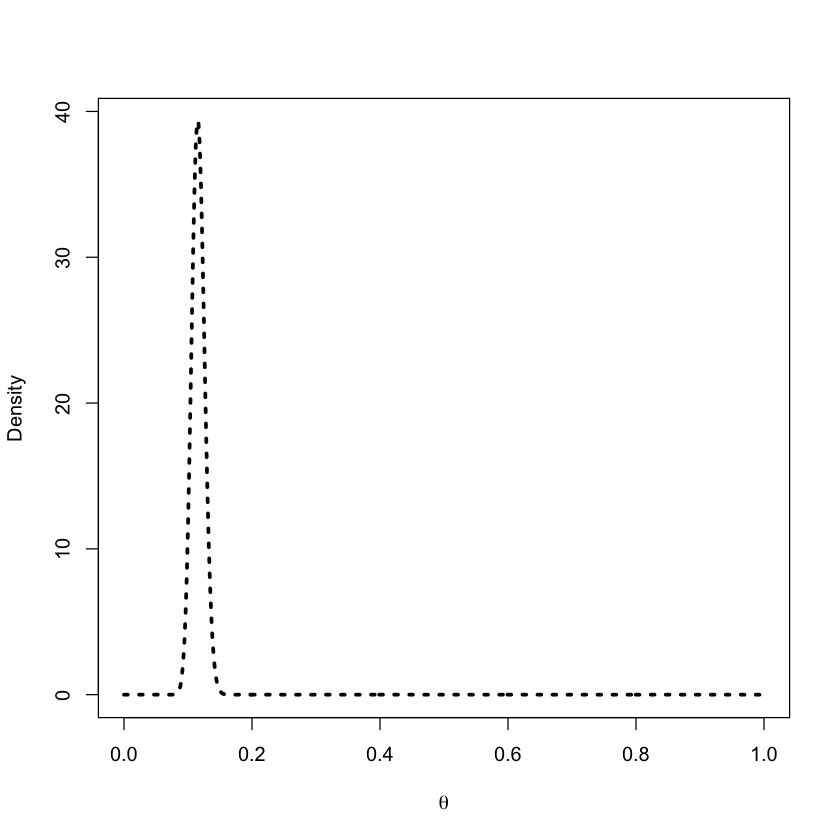

```r
plot(th, post, type='l', ylab = "Density",
lty = 3, lwd = 3, xlab = expression(theta))
```

```r
# 3.d use MCMC
```

```r
# 3.e use MCMC
```

## Problem 4

$f(\theta, \sigma^2| Y) \; \alpha \; (\sigma^2)^{-\frac{v_o}{2}+1} exp(-Av_0 / 2\sigma^2)$

$\prod_{i=1}^{n} (\sigma^2)^{-1/2} exp(\frac{1}{2\sigma^2}(y_i - \theta)^2)$

$\sum_{i}^{} (y_i - \theta)^2 = n(\bar{y} - \theta)^2 + \sum_{i}^{}(y_i - \bar{y})^2 = n(\bar{y} - \theta)^2 + (n-1)s^2$

$f(\theta, \sigma^2| Y) \; \alpha \; (\sigma^2)^{-(v_o+ n + 1)/2} exp(-\frac{v_o A + (n-1) s^2}{2\sigma^2})$

$\alpha \; Normal_\theta(\bar{y}, \frac{\sigma^2}{n}) Inv.Gamma_{\sigma^2}(\frac{v_o + n - 1}{2}, \frac{Av_o + (n-1)s^2}{2})$

## Probelm 5

# Social Network Analysis Module

6) Load the physician Boston-area clinic edgelist dataset “QBS122_ClinEdgeList.csv” andthe associated attribute data set “nodecov.dat” into R (the data sets are on Canvas). The physicians are number from 1 through to 𝑛 = 33. For this question, you may find it helpful to refer to the PhysNetClass.R and PhysLatNetClass.R scripts on Canvas.

a. Plot the network using igraph with the nodes colored by sex (female vs male) and the size of the nodes reflecting whether or not the physician is an expert in women’s health. Are female or male physicians more in the center of the network?

b. Estimate the ERGM model with the edge, mutual, nodeocov(“male”), nodeicov(“male”), and nodematch(“male”,diff=F) statistics.

```
i. Does reciprocity (mutuality) appear to be more prominent than expected by chance?

ii. Interpret the estimated coefficients of the node-out, node-in, and node- match statistics in the model in b(i). Which of these terms is the most dominant?

iii. Conduct a goodness of fit analysis for the model. Print the tables of the goodness of fit statistics for in-degree and out-degree (if you have saved the goodness-of-fit output into an object called xyz use the command print(xyz)) and comment on the extent of the lack-of-fit of the fitted model with respect to the in-degree and the out-degree distributions.

iv. Change nodematch(“male”,diff=F) to nodematch(“male”,diff=T) and re- estimate the model. Monitor the dialogue as the model is estimating and use this to help explain what happens?
```

c. Estimate the latent-space (ERGMM) model with the edge, nodeocov(“male”), nodeicov(“male”), and nodematch(“male”,diff=F) terms. Account for node-level clustering by also including a physician’s propensities to send and receive edges (“ties”) and account for higher-order clustering by including the 2-dimensional Euclidean distance latent-space term with 2 clusters.

```
i. Interpret the sender and receiver random effects. What do their estimated variances say about the amounts of unexplained variability in the extents to which physicians send and receive edges?

ii. Plot the latent-space part of the estimated model. Does the amount of latent-space clustering appear highly pronounced? Describe and estimate a model that you might next estimate to evaluate whether your assessment is correct.
```

```r
library(eigenmodel)
library(latentnet)
library(coda)
library(sna)
library(statnet)
library(igraph)
library(amen)
```

```r
# Load edgelist
edgedata <- read.csv("QBS122_ClinEdgeList.csv")

#Load node covariate data
covdata <- scan('nodecov.dat')
covdata <- matrix(covdata,nrow=33,byrow=T)
nodecov <- list(male=covdata[,2], whexpert=covdata[,3], pctwom=covdata[,4],
 numsess=covdata[,5], practice=covdata[,6])

#Make categorical variables
nodecov$bcma <- ifelse(nodecov$practice==1,1,0)
nodecov$bima <- ifelse(nodecov$practice==2,1,0)
nodecov$bpp <- ifelse(nodecov$practice==3,1,0)
nodecov$wnhlth <- ifelse(nodecov$practice==4,1,0)
nodecov$numcat <- 1+ifelse(nodecov$numsess>2,1,0)+ifelse(nodecov$numsess>6,1,0)
nodecov$pctcat <- 1+ifelse(nodecov$pctwom>50,1,0)+ifelse(nodecov$pctwom>75,1,0)
```

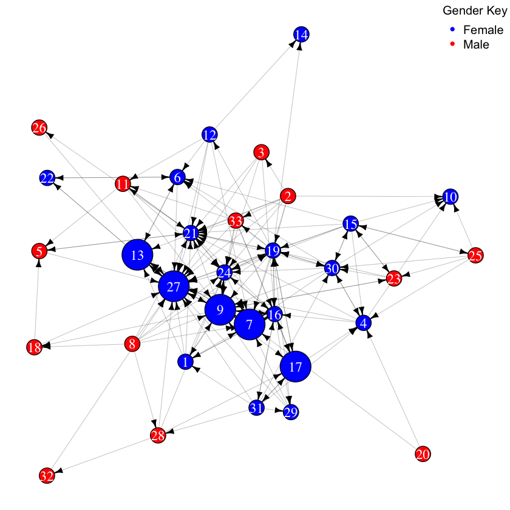

```r
# 6.a)
gnet <- graph_from_data_frame(d=edgedata, vertices=c(1:33), directed=TRUE) #Make graph object
V(gnet)$color <- ifelse(nodecov$male==0,"blue","red")
V(gnet)$size <- nodecov$whexpert*7+7
par(mar=c(0,0,0,0))

plot(gnet,
     vertex.color = V(gnet)$color,
     vertex.size = V(gnet)$size,
     vertex.label.color = "white",
     vertex.label.cex = 1.15,
     edge.color="black",
     edge.arrow.size=0.55, asp = 0,
     layout = layout_with_fr,
     vertex.frame.color = "black",
     edge.width = 0.2)
legend("topright", legend = c("Female","Male"), cex = 1,
col = c('blue','red'), pch = c(20,20,20,20),horiz=F,bty='n',title='Gender Key')
```

### Clearly Females physicians are more in the center of the network

```r
# 6.b)
temp <- graph.data.frame(edgedata)
reldata <- get.adjacency(temp,sparse=FALSE)

pnet <- network(reldata,directed=TRUE,matrixtype="adjacency",
 vertex.attr=nodecov,
 vertex.attrnames=c("male","whexpert","pctwom","numsess","practice",
  "bcma","bima","bpp","wnhlth","numcat","pctcat"))

summary((model6b <- ergm(pnet ~ edges + mutual + nodeocov("male") + nodeicov("male") + nodematch("male",diff=F))))
```

[output not shown]

```
Call:
ergm(formula = pnet ~ edges + mutual + nodeocov("male") + nodeicov("male") +
    nodematch("male", diff = F))

Iterations:  2 out of 20

Monte Carlo MLE Results:
               Estimate Std. Error MCMC % z value Pr(>|z|)
edges          -1.64414    0.20710      0  -7.939   <1e-04 ***
mutual          1.13643    0.28089      0   4.046   <1e-04 ***
nodeocov.male  -0.32410    0.20122      0  -1.611   0.1073
nodeicov.male  -0.48079    0.20458      0  -2.350   0.0188 *
nodematch.male -0.01964    0.18819      0  -0.104   0.9169
---
Signif. codes:  0 ‘***’ 0.001 ‘**’ 0.01 ‘*’ 0.05 ‘.’ 0.1 ‘ ’ 1

     Null Deviance: 1463.9  on 1056  degrees of freedom
 Residual Deviance:  880.2  on 1051  degrees of freedom

AIC: 890.2    BIC: 915    (Smaller is better.)
```

### 6.b.i yes, it is statistically significant positive association.

### 6.b.ii node in is the only node that is statistically significant. All three have negative estimates.

```r
# 6.b. iii )
summary ((model6bcont <- gof(model6b~distance+idegree+odegree+espartners,
                   control=control.gof.formula(nsim=10000),verbose=F)))
```

[output not shown]

```r
print(model6bcont)
```

```
Goodness-of-fit for minimum geodesic distance

    obs min     mean max MC p-value
1   163 116 162.7770 209     1.0000
2   290 284 468.3052 624     0.0002
3   253 222 346.2075 438     0.0048
4   108   1  57.3780 195     0.0954
5    51   0   4.2975  83     0.0016
6     8   0   0.2538  29     0.0124
7     0   0   0.0127  14     1.0000
8     0   0   0.0004   2     1.0000
Inf 183   0  16.7679 212     0.0010

Goodness-of-fit for in-degree

   obs min   mean max MC p-value
0    3   0 0.2864   4     0.0064
1    5   0 1.3146   8     0.0182
2    6   0 3.0341  11     0.1496
3    6   0 4.6817  14     0.6418
4    0   0 5.5808  17     0.0036
5    1   0 5.5761  15     0.0334
6    4   0 4.6899  14     0.9686
7    1   0 3.4527  12     0.2530
8    0   0 2.1853   9     0.2108
9    2   0 1.2183   7     0.6946
10   0   0 0.5942   5     1.0000
11   1   0 0.2486   3     0.4402
12   1   0 0.0911   3     0.1722
13   1   0 0.0327   2     0.0646
14   1   0 0.0091   2     0.0178
15   0   0 0.0031   1     1.0000
16   0   0 0.0009   1     1.0000
17   0   0 0.0004   1     1.0000
24   1   0 0.0000   0     0.0000

Goodness-of-fit for out-degree

   obs min   mean max MC p-value
0    2   0 0.2219   4     0.0474
```

[output cut: 25 more lines]

```
esp4  14   0  1.3131  13     0.0000
esp5   8   0  0.2136   7     0.0000
esp6   3   0  0.0268   4     0.0006
esp7   3   0  0.0026   1     0.0000
esp8   1   0  0.0002   1     0.0004
esp9   1   0  0.0001   1     0.0002

Goodness-of-fit for model statistics

               obs min     mean max MC p-value
edges          163 116 162.7770 209          1
mutual          26   9  25.9757  45          1
nodeocov.male   52  25  51.9559  80          1
nodeicov.male   48  24  47.9823  72          1
nodematch.male  91  58  90.9022 134          1
```

### GOF for model stats is not significant.

```r
# 6.2.iv
summary((model6bT <- ergm(pnet ~ edges + mutual + nodeocov("male") +
                          nodeicov("male") + nodematch("male",diff=T))))
```

```
Starting maximum pseudolikelihood estimation (MPLE):

Evaluating the predictor and response matrix.

Maximizing the pseudolikelihood.

Finished MPLE.

Warning message:
“Model statistics ‘nodematch.male.1’ are linear combinations of some set of preceding statistics at the current stage of the estimation. This may indicate that the model is nonidentifiable.”
Starting Monte Carlo maximum likelihood estimation (MCMLE):

Iteration 1 of at most 20:

Warning message:
“Model statistics ‘nodematch.male.1’ are linear combinations of some set of preceding statistics at the current stage of the estimation. This may indicate that the model is nonidentifiable.”
NOTE: Messages ‘Error in mcexit(0L)...’ may appear; please disregard them.

Optimizing with step length 1.

The log-likelihood improved by 0.002059.

Step length converged once. Increasing MCMC sample size.

Iteration 2 of at most 20:

Warning message:
“Model statistics ‘nodematch.male.1’ are linear combinations of some set of preceding statistics at the current stage of the estimation. This may indicate that the model is nonidentifiable.”
Optimizing with step length 1.

The log-likelihood improved by 0.003094.

Step length converged twice. Stopping.

Finished MCMLE.

Evaluating log-likelihood at the estimate.
Using 20 bridges:
1
2
3
4
5
6
7
8
9
10
11
12
13
14
15
16
17
18
19
20
.

This model was fit using MCMC.  To examine model diagnostics and check
for degeneracy, use the mcmc.diagnostics() function.
```

```
Call:
ergm(formula = pnet ~ edges + mutual + nodeocov("male") + nodeicov("male") +
    nodematch("male", diff = T))

Iterations:  2 out of 20

Monte Carlo MLE Results:
                  Estimate Std. Error MCMC % z value Pr(>|z|)
edges            -1.619887         NA     NA      NA       NA
mutual            1.132059   0.280350      0   4.038   <1e-04 ***
nodeocov.male    -0.347207         NA     NA      NA       NA
nodeicov.male    -0.496873         NA     NA      NA       NA
nodematch.male.0 -0.039361         NA     NA      NA       NA
nodematch.male.1 -0.001736         NA     NA      NA       NA
---
Signif. codes:  0 ‘***’ 0.001 ‘**’ 0.01 ‘*’ 0.05 ‘.’ 0.1 ‘ ’ 1

     Null Deviance: 1463.9  on 1056  degrees of freedom
 Residual Deviance:  880.2  on 1050  degrees of freedom

AIC: 892.2    BIC: 922    (Smaller is better.)
```

### only mutual stays

```r
# 6.c.i)
summary((model6c <- ergmm(pnet~rreceiver+rsender+euclidean(d=2,G=2)+
                    edges+nodeocov("male")+nodeicov("male")+nodematch("male",diff=F))))
```

```
==========================
Summary of model fit
==========================

Formula:   pnet ~ rreceiver + rsender + euclidean(d = 2, G = 2) + edges +
    nodeocov("male") + nodeicov("male") + nodematch("male", diff = F)
Attribute: edges
Model:     Bernoulli
MCMC sample of size 4000, draws are 10 iterations apart, after burnin of 10000 iterations.
Covariate coefficients posterior means:
                 Estimate       2.5%  97.5% 2*min(Pr(>0),Pr(<0))
edges           1.1763798  0.0089813 2.4610               0.0475 *
nodeocov.male  -0.5857881 -1.6096922 0.5570               0.2720
nodeicov.male  -1.0897672 -2.4162647 0.2811               0.1125
nodematch.male -0.0732409 -0.6983428 0.5335               0.7945
---
Signif. codes:  0 ‘***’ 0.001 ‘**’ 0.01 ‘*’ 0.05 ‘.’ 0.1 ‘ ’ 1

Sender effect variance: 1.232363.
Receiver effect variance: 2.714572.
Overall BIC:        980.2586
Likelihood BIC:     503.5125
Latent space/clustering BIC:     245.6242
Sender effect BIC:     108.9524
Receiver effect BIC:     122.1695

Covariate coefficients MKL:
                 Estimate
edges           0.4957900
nodeocov.male  -0.9217237
nodeicov.male  -0.6640347
nodematch.male -0.1187115
```

### Reciever effect explains more of the effect with the edges every physician receives (double the variance effect of sender.

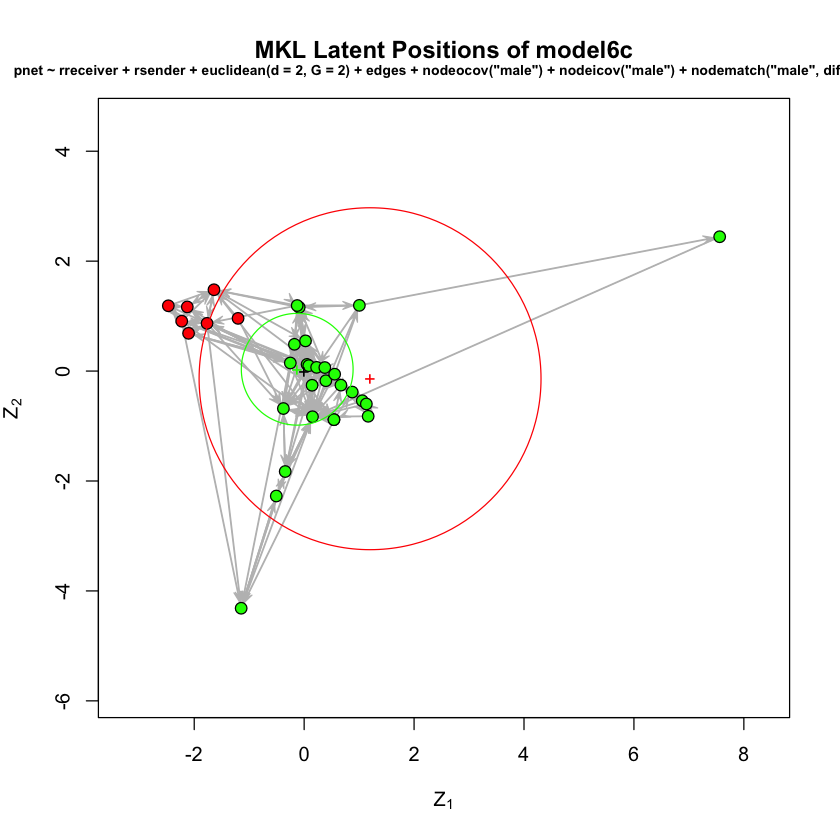

```r
# 6. c. ii

plot(model6c)
```

## Problem 7

Load the physician Boston-area clinic adjacency matrix dataset “QBS122_PhysPract.txt” and the associated attribute data set “nodecov.dat” into R (the files are on Canvas). The physicians are ordered the same in both datasets. For this question, you may find it helpful to refer to the PhysEgoClass.R script on canvas; this in turn reads in NetAnalFns.r, which is also available on Canvas.

a. Form the weight (W) matrix from the adjacency matrix for the network in which any conversation about women’s health constitutes an edge. Make the matrix row-stochastic by scaling the elements such that the rows of all actors with an outdegree other than 0 sum to 1. Confirm that the row sums of the resulting W equal 1 for all actors whose out-degree is > 0.

b. Estimate the autocorrelated outcome model for the peer-effect of the physician attribute “sumhrt”, the number of patients who have undergone hormone replacement therapy (HRT), adjusting for male and the indicator of whether an actor has an out-degree of 0 (the variable defined as noalters in PhysEgoClass.R). Be sure to include an intercept. Interpret the estimated peer-effect.

c. Re-estimate the model in (b) but without an intercept. Comment on the change in the estimated peer-effect and explain why this occurs. Is the model in (b) or the model in (c) more suitable?

```r
# Load adjacency matrix
reldata <- scan('QBS122_PhysPract.txt')
nr=sqrt(length(reldata))
reldata=matrix(reldata,ncol=nr,nrow=nr,byrow=T)

#Load node covariate data
covdata <- scan('nodecov.dat')
covdata <- matrix(covdata,nrow=nr,byrow=T)
colnames(covdata) <- c("id","male","whexpert","pctwom",
"numsess","practice","sumhrt")
covdata <- data.frame(covdata)
nodecov <- list(male=covdata[,2], whexpert=covdata[,3], pctwom=covdata[,4],
 numsess=covdata[,5], practice=covdata[,6])

#Add categorical predictors
nodecov$bcma <- ifelse(nodecov$practice==1,1,0)
nodecov$bima <- ifelse(nodecov$practice==2,1,0)
nodecov$bpp <- ifelse(nodecov$practice==3,1,0)
nodecov$wnhlth <- ifelse(nodecov$practice==4,1,0)
nodecov$numcat <- 1+ifelse(nodecov$numsess>2,1,0)+ifelse(nodecov$numsess>6,1,0)
nodecov$pctcat <- 1+ifelse(nodecov$pctwom>50,1,0)+ifelse(nodecov$pctwom>75,1,0)
```

```r
# 7.a
weight <- sna::make.stochastic(reldata, mode="row")
for ( i in 1:33){ print(sum(weight[i,]))} # should sum up to one for those who out-degree is > 0
```

```
[1] 1
[1] 1
[1] 1
[1] 1
[1] 1
[1] 1
[1] 1
[1] 1
[1] 1
[1] 0
[1] 1
[1] 1
[1] 1
[1] 0
[1] 1
```

[output cut: 18 more lines]

```r
# 7.b
n <- ifelse(rowSums(weight)==0,1,0) # replace zeros with 1s
h<- weight %*% as.vector(covdata$sumhrt)

regdata <- data.frame(covdata,hrtalt=h,noalters=n)

inter <- as.vector(rep(1,33)) # intercept included

x <- as.matrix(cbind(on,regdata[,c("male","pctwom","noalters")]))

summary(lnam <- lnam(regdata$sumhrt,x,NULL,weight))
```

```
Call:
lnam(y = regdata$sumhrt, x = x, W1 = NULL, W2 = weight)

Residuals:
    Min      1Q  Median      3Q     Max
-6.9207 -2.3141  0.7441  3.1058  6.1058

Coefficients:
         Estimate Std. Error Z value Pr(>|z|)
on       17.06865    4.61325   3.700 0.000216 ***
male      0.72682    2.46338   0.295 0.767954
pctwom   -0.04233    0.05550  -0.763 0.445674
noalters -2.31977    2.79183  -0.831 0.406022
rho2.1    0.14365    0.38057   0.377 0.705831
---
Signif. codes:  0 ‘***’ 0.001 ‘**’ 0.01 ‘*’ 0.05 ‘.’ 0.1 ‘ ’ 1

      Estimate Std. Error
Sigma    3.419      0.177

Goodness-of-Fit:
	Residual standard error: 3.726 on 28 degrees of freedom (w/o Sigma)
	Multiple R-Squared: 0.1418, Adjusted R-Squared: -0.01149
	Model log likelihood: -87.42 on 27 degrees of freedom (w/Sigma)
	AIC: 186.8 BIC: 195.8

	Null model: meanstd
	Null log likelihood: -89.8 on 31 degrees of freedom
	AIC: 183.6 BIC: 186.6
	AIC difference (model versus null): -3.244
	Heuristic Log Bayes Factor (model versus null):  -9.23
```

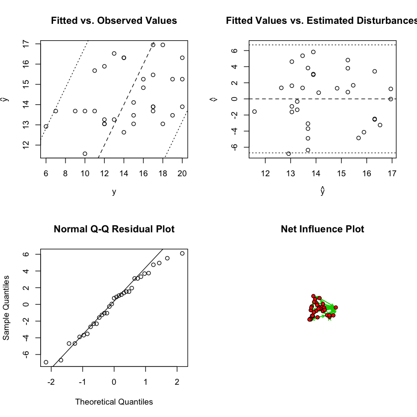

```r
plot(lnam)
```

### no independent variables are statistically significant in the autocorrelated outcome model. Normally distributed from Q-Q plot. The intercept is statistically significant.

```r
# 7.c
n <- ifelse(rowSums(weight)==0,1,0) # replace zeros with 1s
h<- weight %*% as.vector(covdata$sumhrt)

regdata <- data.frame(covdata,hrtalt=h,noalters=n)


summary(lnam<- lnam(regdata$sumhrt,x[,2:4],NULL,weight))
```

```
Call:
lnam(y = regdata$sumhrt, x = x[, 2:4], W1 = NULL, W2 = weight)

Residuals:
    Min      1Q  Median      3Q     Max
-9.4362 -2.9637 -0.3472  4.0929  8.1866

Coefficients:
          Estimate Std. Error Z value Pr(>|z|)
male      8.834220   1.302925   6.780  1.2e-11 ***
pctwom    0.157512   0.009586  16.432  < 2e-16 ***
noalters  2.031440   2.975860   0.683    0.495
rho2.1   -0.280828   0.381593  -0.736    0.462
---
Signif. codes:  0 ‘***’ 0.001 ‘**’ 0.01 ‘*’ 0.05 ‘.’ 0.1 ‘ ’ 1

      Estimate Std. Error
Sigma    4.081      0.253

Goodness-of-Fit:
	Residual standard error: 4.406 on 29 degrees of freedom (w/o Sigma)
	Multiple R-Squared: 0.2384, Adjusted R-Squared: 0.1334
	Model log likelihood: -93.31 on 28 degrees of freedom (w/Sigma)
	AIC: 196.6 BIC: 204.1

	Null model: meanstd
	Null log likelihood: -89.8 on 31 degrees of freedom
	AIC: 183.6 BIC: 186.6
	AIC difference (model versus null): -13.02
	Heuristic Log Bayes Factor (model versus null):  -17.51
```

### When intercept is dropped the pctwom and male becomes stat significant and have a positive association. Distribution is a little skewed from Q-Q plot.

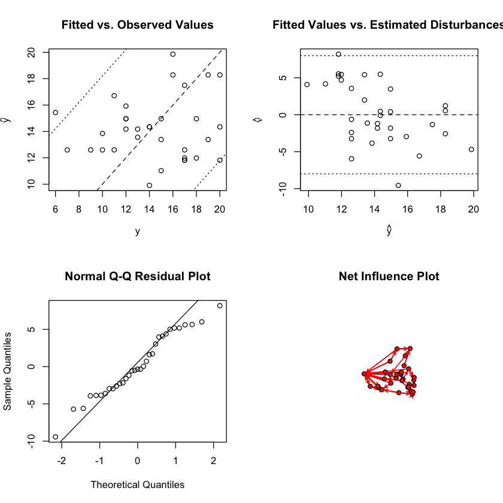

```r
plot(lnam)
```